# Selfstudy 3

Rasmus Dam, Jonas Brunholm Jensen, Asbjørn Bach Andreasen, Jonas Svejstrup Mikkelsen

# Introduction

This self study assignment should be answered using a single Rmd file which can be run on one of the university servers js{01,02,03,04} in a reasonable amount of time. Please add student name in the yaml header (if you are a group of students working together you are allowed to only hand in one answer with all your names on it).

# Interest rate data

In this exercise we consider a classical dataset of US interest rates from medio 1964 to medio 1989 from the package `Ecdat`:

```r
data(Irates, package = "Ecdat")
rates <- Irates[, "r1"]
X <- window(rates, start = 1964.471, end = 1989.333)
```

## CIR model

$$d X_t = (\theta_1 - \theta_2 X_t) dt + \theta_3 \sqrt{X_t} d W_t, \quad X_0 = x_0 > 0$$

## Problem A

Use full maximum likelihood to fit the Cox-Ingersoll-Ross model to the dataset using the `sde` package as described in Iacus (2008).

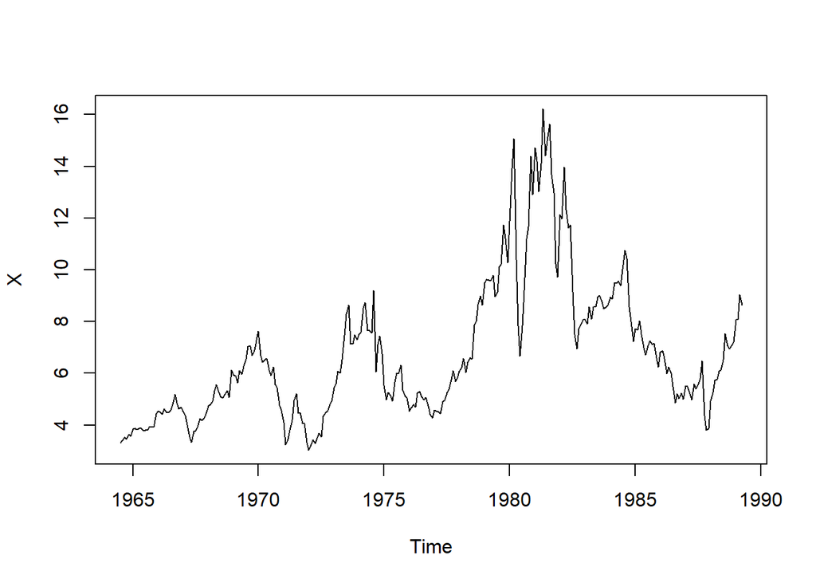

```r
suppressMessages(library(sde))

plot.ts(X)
```

```r
CIR.lik <- function(theta1, theta2, theta3) {
  n <- length(X)
  dt <- deltat(X)
  -sum(dcCIR(
    x = X [2:n], Dt = dt, x0 = X [1:(n - 1)], theta = c(theta1, theta2, theta3),
    log = T
  ))
}


mle(CIR.lik, start = list(theta1 = 3, theta2 = 0.5, theta3 = 1), method = "L-BFGS-B", lower = c(-Inf, 0, 0))
```

```
##
## Call:
## mle(minuslogl = CIR.lik, start = list(theta1 = 3, theta2 = 0.5,
##     theta3 = 1), method = "L-BFGS-B", lower = c(-Inf, 0, 0))
##
## Coefficients:
##    theta1    theta2    theta3
## 3.4906518 0.4866842 0.8948196
```

## Problem B

Use the Euler pseudo likelihood to fit the Cox-Ingersoll-Ross model to the dataset using the `sde` package as described in Iacus (2008).

```r
d <- function(t, x, theta) {
  theta[1] - theta[2] * x
}

s <- function(t, x, theta) {
  theta[3] * sqrt(x)
}

Euler_CIR <- function(theta1, theta2, theta3) {
  theta <- c(theta1, theta2, theta3)
  n <- length(X)
  dt <- deltat(X)
  -sum(dcEuler(x = X[2:n], t = dt, x0 = X[1:n - 1],t0 = 0, theta = theta, d = d, s = s, log = T))
}

mle(Euler_CIR, start = list(theta1 = 3, theta2 = 0.5, theta3 = 1), method = "L-BFGS-B", lower = c(-Inf, 0, 0))
```

```
##
## Call:
## mle(minuslogl = Euler_CIR, start = list(theta1 = 3, theta2 = 0.5,
##     theta3 = 1), method = "L-BFGS-B", lower = c(-Inf, 0, 0))
##
## Coefficients:
##    theta1    theta2    theta3
## 2.6387616 0.3606087 0.8650745
```

## Problem C

Generate 1000 simulations of one of the fitted models, with `N = 1000` time steps and the same start and end time and starting value as the dataset `X` (note the time step (frequency) of the simulations will be different than for the dataset).

Calculate the mean path and the 2.5 and 97.5 percentile at each time point and plot these three curves together with the data.

Is there any part of the data that looks suspicious compared to the fitted model?

For the CIR model we can calculate the invariant distribution as a (scaled) $\chi^2$ distribution. This can be found at the bottom of p. 48 in Iacus (2008) by letting $t\to\infty$.

Add the two corresponding theoretical percentiles as horizontal lines in the plot.

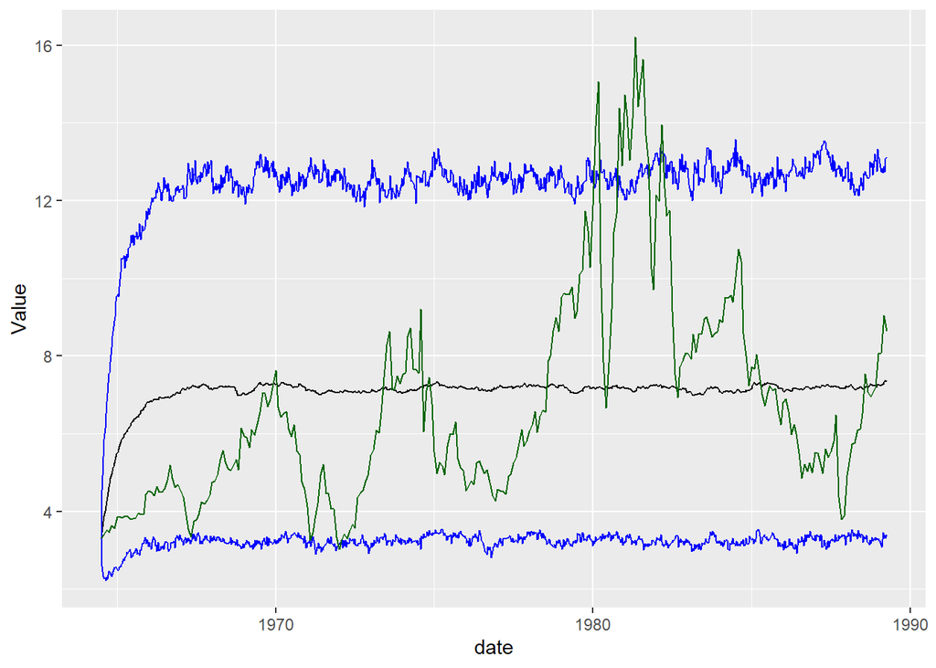

```r
suppressMessages(library(tidyverse))

theta <- c(3.4906518,0.4866842,0.8948196)


result_sim_CIR <- suppressMessages(sde.sim(t0 = 0,
        X0 = X[1],
        N = 1000,
        delta = deltat(X),
        method = "euler",
        theta = theta,
        model = "CIR",
        M = 1000))


mean_path <- result_sim_CIR %>% apply(., 1, mean)
low_percentile <- result_sim_CIR %>% apply(., 1, function (x) quantile(x, probs = 0.025))
high_percentile <- result_sim_CIR %>% apply(., 1, function (x) quantile(x, probs = 0.975))


plot_data <- data.frame(date = seq.Date(from = lubridate::date("1964-07-01"),
                                        to = lubridate::date("1989-04-01"), length.out = 1001),
                        mean = mean_path,
                        q_low = low_percentile,
                        q_high = high_percentile)

plot_X <- data.frame(date = seq.Date(from = lubridate::date("1964-07-01"),
                                        to = lubridate::date("1989-04-01"), length.out = 298),
                     X = X)

plot <- ggplot(data = plot_data, aes(x = date)) +
  geom_line(aes(y = mean), color = "black") +
  geom_line(aes(y = q_low), color = "blue") +
  geom_line(aes(y = q_high), color = "blue") +
  geom_line(aes(x = date, y = X), color = "darkgreen", data = plot_X) +
  labs(y = "Value")

plot
```

Q: Is there any part of the data that looks suspicious compared to the fitted model?

A: There is a part of the data that stays outside the confidence bounds for some time, except for that, nothing is suspicous.

## Quantiles from gamma distribution

```r
gamma_quants <- qgamma(p = c(0.025,0.975), shape = (2*theta[1] )/ ((theta[3])^2), scale = (theta[3]^2) / (2* theta[2]))
gamma_quants
```

```
## [1]  3.230768 12.658748
```

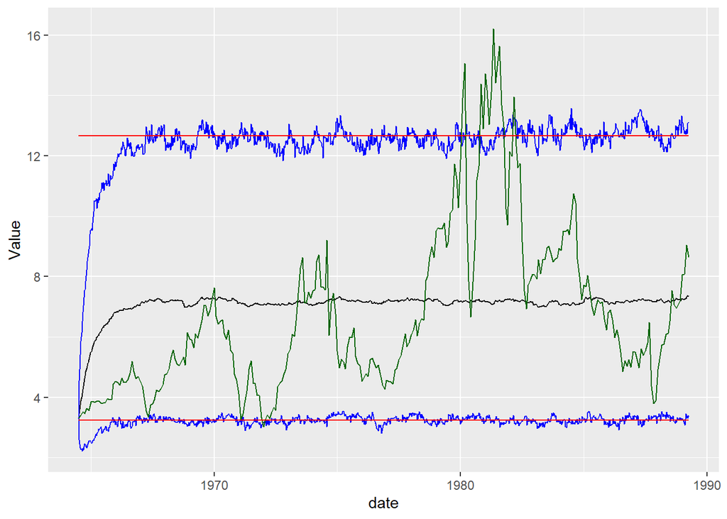

```r
plot + geom_line(aes(y = gamma_quants[1]), color = "red") +
  geom_line(aes(y = gamma_quants[2]), color = "red")
```